# Modele nieparametryczne - Marcel Bilski

Marcel Bilski

## Pakiety

[output not shown]

[output not shown]

[output not shown]

[output not shown]

[output not shown]

[output not shown]

[output not shown]

[output not shown]

[output not shown]

[output not shown]

[output not shown]

[output not shown]

[output not shown]

[output not shown]

## ZADANIE 1 - Wstępna analiza

```r
load("dane_zaliczenie.RData")
summary(proba_uczaca)
```

```
##        id         initialtransaction_id   createtime
##  Min.   :    17   Min.   :    17        Min.   :2020-01-09 00:07:19.93
##  1st Qu.: 43403   1st Qu.:  1673        1st Qu.:2020-10-23 11:28:57.19
##  Median : 81757   Median : 25840        Median :2021-01-30 07:07:54.65
##  Mean   : 81363   Mean   : 37567        Mean   :2021-01-18 22:17:09.17
##  3rd Qu.:120964   3rd Qu.: 64465        3rd Qu.:2021-04-27 10:53:33.77
##  Max.   :162463   Max.   :162231        Max.   :2021-07-07 23:51:06.22
##                   NA's   :3961
##      amount        browseragent       description        recurringaction
##  Min.   :   0.81   Length:29412       Length:29412       Length:29412
##  1st Qu.:  15.00   Class :character   Class :character   Class :character
##  Median :  30.00   Mode  :character   Mode  :character   Mode  :character
##  Mean   :  59.66
##  3rd Qu.:  50.00
##  Max.   :3450.58
##
##  screenheight       screenwidth        acquirerconnectionmethod  expirymonth
##  Length:29412       Length:29412       Length:29412             Min.   : 1.0
##  Class :character   Class :character   Class :character         1st Qu.: 3.0
##  Mode  :character   Mode  :character   Mode  :character         Median : 7.0
##                                                                 Mean   : 6.5
##                                                                 3rd Qu.: 9.0
##                                                                 Max.   :12.0
##
##    expiryyear      issuer              type              level
##  Min.   :2020   Length:29412       Length:29412       Length:29412
##  1st Qu.:2022   Class :character   Class :character   Class :character
##  Median :2023   Mode  :character   Mode  :character   Mode  :character
##  Mean   :2023
##  3rd Qu.:2024
##  Max.   :2029
##
##  countrycode          listtype           mccname
##  Length:29412       Length:29412       Length:29412
##  Class :character   Class :character   Class :character
##  Mode  :character   Mode  :character   Mode  :character
##
##
##
##
##  payclickedtime                                      status
##  Min.   :2020-01-09 00:09:12.56   bank declined         :   42
##  1st Qu.:2020-07-16 13:30:03.16   card limit exceeded   : 4618
##  Median :2020-11-12 17:09:25.72   do not honor          :  404
##  Mean   :2020-11-06 16:49:59.89   completed successfully:20387
##  3rd Qu.:2021-03-06 07:39:37.21   NA's                  : 3961
##  Max.   :2021-07-07 15:34:35.88
##  NA's   :25451
```

```r
sum(is.na(proba_uczaca))
```

```
## [1] 121478
```

```r
sapply(proba_uczaca, function(x) sum(is.na(x)))
```

```
##                       id    initialtransaction_id               createtime
##                        0                     3961                        0
##                   amount             browseragent              description
##                        0                    25451                     3830
##          recurringaction             screenheight              screenwidth
##                        0                    25451                    25451
## acquirerconnectionmethod              expirymonth               expiryyear
##                        0                        0                        0
##                   issuer                     type                    level
##                        0                        0                        0
##              countrycode                 listtype                  mccname
##                        0                     3961                     3961
##           payclickedtime                   status
##                    25451                     3961
```

## Usunięcie kolumn

Usunięcie niepotrzebnych kolumn.

```r
proba_uczaca <- proba_uczaca %>% select(-screenwidth, -screenheight, -payclickedtime, -browseragent, -description)
summary(proba_uczaca)
```

```
##        id         initialtransaction_id   createtime
##  Min.   :    17   Min.   :    17        Min.   :2020-01-09 00:07:19.93
##  1st Qu.: 43403   1st Qu.:  1673        1st Qu.:2020-10-23 11:28:57.19
##  Median : 81757   Median : 25840        Median :2021-01-30 07:07:54.65
##  Mean   : 81363   Mean   : 37567        Mean   :2021-01-18 22:17:09.17
##  3rd Qu.:120964   3rd Qu.: 64465        3rd Qu.:2021-04-27 10:53:33.77
##  Max.   :162463   Max.   :162231        Max.   :2021-07-07 23:51:06.22
##                   NA's   :3961
##      amount        recurringaction    acquirerconnectionmethod  expirymonth
##  Min.   :   0.81   Length:29412       Length:29412             Min.   : 1.0
##  1st Qu.:  15.00   Class :character   Class :character         1st Qu.: 3.0
##  Median :  30.00   Mode  :character   Mode  :character         Median : 7.0
##  Mean   :  59.66                                               Mean   : 6.5
##  3rd Qu.:  50.00                                               3rd Qu.: 9.0
##  Max.   :3450.58                                               Max.   :12.0
##
##    expiryyear      issuer              type              level
##  Min.   :2020   Length:29412       Length:29412       Length:29412
##  1st Qu.:2022   Class :character   Class :character   Class :character
##  Median :2023   Mode  :character   Mode  :character   Mode  :character
##  Mean   :2023
##  3rd Qu.:2024
##  Max.   :2029
##
##  countrycode          listtype           mccname
##  Length:29412       Length:29412       Length:29412
##  Class :character   Class :character   Class :character
##  Mode  :character   Mode  :character   Mode  :character
##
##
##
##
##                     status
##  bank declined         :   42
##  card limit exceeded   : 4618
##  do not honor          :  404
##  completed successfully:20387
##  NA's                  : 3961
##
##
```

## Weryfikacja powiązania

NA występuje dla transakcji inicjalizyjących. Możliwa jest zatem imputacja jako ‘completed successfully’. Możemy zweryfikować czy braki danych w zmiennych status i initialtransaction_id są powiązane z zmienną recurringaction.

```r
# Tworzenie pomocniczej tabeli i filtrowanie braków danych w 'initialtransaction_id'
help_table1 <- proba_uczaca %>%
  select(status, initialtransaction_id, recurringaction) %>%
  filter(is.na(initialtransaction_id))

# Podsumowanie informacji
summary(help_table1)
```

```
##                     status     initialtransaction_id recurringaction
##  bank declined         :   0   Min.   : NA           Length:3961
##  card limit exceeded   :   0   1st Qu.: NA           Class :character
##  do not honor          :   0   Median : NA           Mode  :character
##  completed successfully:   0   Mean   :NaN
##  NA's                  :3961   3rd Qu.: NA
##                                Max.   : NA
##                                NA's   :3961
```

```r
# Sprawdzanie liczby braków w poszczególnych zmiennych
sum_na_initialtransaction_id <- sum(is.na(help_table1$initialtransaction_id))
sum_na_status <- sum(is.na(help_table1$status))

# Wyświetlenie unikalnych transakcji z brakami danych
unique_transactions_with_na <- unique(help_table1)

# Uzupełnianie braków danych w 'status' w 'proba_uczaca'
proba_uczaca <- proba_uczaca %>%
  mutate(status = as.character(status)) %>%
  mutate(status = ifelse(is.na(status), "completed successfully", status))

# Sprawdzenie unikalnych wartości po uzupełnieniu braków
unique(proba_uczaca$status)
```

```
## [1] "completed successfully" "card limit exceeded"    "bank declined"
## [4] "do not honor"
```

```r
# Liczenie pozostałych braków w 'status'
sum_na_status_after <- sum(is.na(proba_uczaca$status))

# Konwersja 'status' na faktor
proba_uczaca$status <- as.factor(proba_uczaca$status)
levels(proba_uczaca$status)
```

```
## [1] "bank declined"          "card limit exceeded"    "completed successfully"
## [4] "do not honor"
```

## Dalsza weryfikacja

Sprawdzamy czy inne zmienne z wartością NA mają jakieś powiązania. W tym celu tworzy dwie nowe tabele pomocnicze.

```r
help_table2 <- proba_uczaca[,c('status', 'mccname', 'listtype', 'initialtransaction_id', 'recurringaction')]
help_table3 <- filter(help_table2, is.na(help_table2$initialtransaction_id))
summary(help_table3)
```

```
##                     status       mccname            listtype
##  bank declined         :   0   Length:3961        Length:3961
##  card limit exceeded   :   0   Class :character   Class :character
##  completed successfully:3961   Mode  :character   Mode  :character
##  do not honor          :   0
##
##
##
##  initialtransaction_id recurringaction
##  Min.   : NA           Length:3961
##  1st Qu.: NA           Class :character
##  Median : NA           Mode  :character
##  Mean   :NaN
##  3rd Qu.: NA
##  Max.   : NA
##  NA's   :3961
```

```r
help_table2$recurringaction <- as.factor(help_table2$recurringaction)

sum(is.na(help_table2$mccname))
```

```
## [1] 3961
```

```r
sum(is.na(help_table2$listtype))
```

```
## [1] 3961
```

```r
sum(is.na(help_table2$initialtransaction_id))
```

```
## [1] 3961
```

## Ogarniczenie zbioru do transakcji AUTO

```r
proba_uczaca <- proba_uczaca %>% filter(proba_uczaca$recurringaction == 'AUTO')

unique(proba_uczaca$recurringaction)
```

```
## [1] "AUTO"
```

```r
#wyczyszczenie kolumny
proba_uczaca <- proba_uczaca %>% select(-recurringaction)
```

## Analiza zmiennej createtime na kolumnę z dniami tygodnia

```r
proba_uczaca$weekday <-  as.factor(weekdays(as.Date(proba_uczaca$createtime)))
proba_uczaca <- proba_uczaca %>%
  mutate(weekday = weekdays(as.Date(createtime)),
         hour = as.numeric(format(as.POSIXct(createtime), "%H")))

proba_uczaca <- proba_uczaca %>% select(-createtime)
```

##Test korelacji chi-kwadrat

```r
for(c in colnames(proba_uczaca)){

  if (class(proba_uczaca[[c]]) == 'character'){
    proba_uczaca[[c]] <- as.factor(proba_uczaca[[c]])
    print(c)
  }
    else {
      print(class(proba_uczaca[[c]]))
    }
}
```

```
## [1] "integer"
## [1] "integer"
## [1] "numeric"
## [1] "acquirerconnectionmethod"
## [1] "integer"
## [1] "integer"
## [1] "issuer"
## [1] "type"
## [1] "level"
## [1] "countrycode"
## [1] "listtype"
## [1] "mccname"
## [1] "factor"
## [1] "weekday"
## [1] "numeric"
```

```r
summary(proba_uczaca$level)
```

```
##               BLACK            BUSINESS             CLASSIC        CLASSIC/GOLD
##                   1                2234                9224                  12
##           CORPORATE       CORPORATE T&E            ELECTRON            ENHANCED
##                 106                  10                 930                   2
##                GOLD       GOLD/PLATINUM       GOLD/STANDARD            INFINITE
##                2458                   1                   7                  13
##  INFINITE/SIGNATURE           NEW WORLD               OTHER            PERSONAL
##                   1                  25                   2                 120
##            PLATINUM             PREPAID    PREPAID PLATINUM  PREPAID RELOADABLE
##                 338                 503                  17                  35
##             REWARDS           SIGNATURE            STANDARD STANDARD UNEMBOSSED
##                   4                   8                8800                  42
##       STANDARD/GOLD      STANDARD/WORLD            TITANIUM               WORLD
##                   1                   1                   1                 543
##         WORLD BLACK WORLD BLACK EDITION         WORLD ELITE
##                   4                   4                   4
```

```r
summary(proba_uczaca$countrycode)
```

```
##    AE    AZ    BY    CA    CL    CO    CY    CZ    DE    DK    EC    FR    GB
##     4    16   144     2    17     1     9    12    31    12     2    15  1176
##    GE    IE    IN    IS    IT    JP    KR    KZ    MD    NL    NO    PK    PL
##     1     9    17    24     1     4     1    29    44     4    65     1 23192
##    RO    RS    RU    SE    TR    UA    US
##    10     2    37     4    77   352   136
```

## Korelacja chi-kwadrat dla zmiennych jakościowych

Wartość p-value w tescie chi-kwadrat pozwoli sprawdzić istotność zmiennych.

```r
# Funkcja do przeprowadzenia testu chi-kwadrat dla grupy zmiennych kategorycznych
chi_square_test <- function(data, target_var) {
  results <- data.frame(Variable = character(),
                        Chi_Square = numeric(),
                        P_Value = numeric(),
                        Degrees_of_Freedom = integer(),
                        stringsAsFactors = FALSE)

  for (col in colnames(data)) {
    if (col != target_var && is.factor(data[[col]])) {
      # Tworzenie tabeli kontyngencji
      contingency_table <- table(data[[target_var]], data[[col]])

      # Test chi-kwadrat
      test <- chisq.test(contingency_table)

      # Zbieranie wyników
      results <- rbind(results, data.frame(Variable = col,
                                           Chi_Square = test$statistic,
                                           P_Value = test$p.value,
                                           Degrees_of_Freedom = test$parameter))
    }
  }
  return(results)
}

# Wyniki testu chi-kwadrat
chi_square_results <- chi_square_test(proba_uczaca, "status")
print(chi_square_results)
```

```
##                            Variable Chi_Square       P_Value Degrees_of_Freedom
## X-squared  acquirerconnectionmethod  957.81528 2.547343e-207                  3
## X-squared1                   issuer   27.77769  1.034663e-04                  6
## X-squared2                     type  349.47538  1.937631e-75                  3
## X-squared3                    level 1333.56964 1.902836e-220                 90
## X-squared4              countrycode 1439.29162 2.306740e-238                 96
## X-squared5                 listtype  283.55390  2.724961e-58                  6
## X-squared6                  mccname  660.10973 1.632240e-128                 18
## X-squared7                  weekday   89.22973  1.984809e-11                 18
```

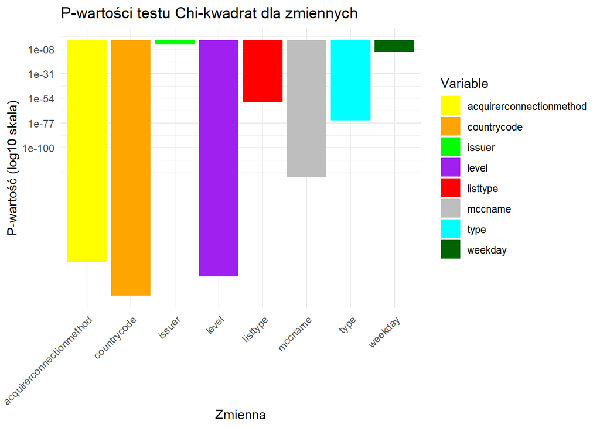

```r
# Histogram z nowymi kolorami
ggplot(chi_square_results, aes(x = Variable, y = P_Value, fill = Variable)) +
  geom_bar(stat = "identity") +
  scale_y_log10() +  # Skala logarytmiczna dla p-wartości
  theme_minimal() +
  theme(axis.text.x = element_text(angle = 45, hjust = 1)) +
  labs(title = "P-wartości testu Chi-kwadrat dla zmiennych", x = "Zmienna", y = "P-wartość (log10 skala)") +
  scale_fill_manual(values = c("yellow", "orange", "green", "purple", "red", "grey", "cyan", "darkgreen"))
```

## Sprawdzenie istotności ilościowych

```r
library(randomForest)
model_rf <- randomForest(status ~ ., data = proba_uczaca)
print(model_rf)
```

```
##
## Call:
##  randomForest(formula = status ~ ., data = proba_uczaca)
##                Type of random forest: classification
##                      Number of trees: 500
## No. of variables tried at each split: 3
##
##         OOB estimate of  error rate: 9.51%
## Confusion matrix:
##                        bank declined card limit exceeded completed successfully
## bank declined                      7                  14                     17
## card limit exceeded                0                3018                   1595
## completed successfully             0                 552                  19820
## do not honor                       0                  35                    184
##                        do not honor class.error
## bank declined                     4  0.83333333
## card limit exceeded               5  0.34647033
## completed successfully           15  0.02781184
## do not honor                    185  0.54207921
```

```r
importance(model_rf)
```

```
##                          MeanDecreaseGini
## id                              1329.3769
## initialtransaction_id           1041.4965
## amount                           772.2414
## acquirerconnectionmethod         145.0355
## expirymonth                      576.2322
## expiryyear                       430.0981
## issuer                           107.2627
## type                             104.9829
## level                            499.1036
## countrycode                      274.4355
## listtype                         112.8108
## mccname                          243.5801
## weekday                          554.6200
## hour                             792.1348
```

# Tworzenie modelu testowego

Powtarzamy to co zrobiliśmy na próbie uczącej tylko na próbie testowej.

```r
proba_testowa <- proba_testowa %>% filter(proba_testowa$recurringaction == 'AUTO')
proba_testowa <- proba_testowa %>% select(-screenwidth, -screenheight, -payclickedtime, -browseragent, -description, -recurringaction, -level, -countrycode)


proba_testowa$weekday <-  as.factor(weekdays(as.Date(proba_testowa$createtime)))
proba_testowa <- proba_testowa %>%
  mutate(weekday = weekdays(as.Date(createtime)),
         hour = as.numeric(format(as.POSIXct(createtime), "%H")))


sum(is.na(proba_testowa))
```

```
## [1] 13484
```

```r
for (col in colnames(proba_testowa)){
   print(col)
   print(sum(is.na(proba_testowa[[col]])))
}
```

```
## [1] "id"
## [1] 0
## [1] "initialtransaction_id"
## [1] 0
## [1] "createtime"
## [1] 0
## [1] "amount"
## [1] 13484
## [1] "acquirerconnectionmethod"
## [1] 0
## [1] "expirymonth"
## [1] 0
## [1] "expiryyear"
## [1] 0
## [1] "issuer"
## [1] 0
## [1] "type"
## [1] 0
## [1] "listtype"
## [1] 0
## [1] "mccname"
## [1] 0
## [1] "weekday"
## [1] 0
## [1] "hour"
## [1] 0
```

```r
proba_testowa <- proba_testowa %>% select(-createtime, -amount)

#zmieniamy na factor
for(c in colnames(proba_testowa)){

  if (class(proba_testowa[[c]]) == 'character'){
    proba_testowa[[c]] <- as.factor(proba_testowa[[c]])
    print(c)
  }
    else {
      print(class(proba_testowa[[c]]))
    }
}
```

```
## [1] "integer"
## [1] "integer"
## [1] "acquirerconnectionmethod"
## [1] "integer"
## [1] "integer"
## [1] "issuer"
## [1] "type"
## [1] "listtype"
## [1] "mccname"
## [1] "weekday"
## [1] "numeric"
```

## Przypisanie kolumny status do kolumny new_status

Dzięki temu będzie możliwe zdecydować czy transakcja zakończyła się sukcesem czy nie.

```r
length(unique(proba_uczaca$mccname))
```

```
## [1] 7
```

```r
table(proba_uczaca$mccname)
```

```
##
##                                              NULL
##                                               694
##                                       Restauracja
##                                                22
##             Sieci komputerowe usługi informacyjne
##                                              5885
##                                Sklepy kosmetyczne
##                                                 1
##                            Sklepy spożywcze różne
##                                                83
##                                     Ubezpieczenia
##                                               561
## Usługi biznesowe gdzie indziej nie sklasyfikowane
##                                             18205
```

```r
nlevels(proba_uczaca$mccname)
```

```
## [1] 7
```

# Przeniesienie nie potrzbenej wartości

Wartość “sklepy kosmetyczne pojawia się tylko raz, więc ją przenosimy, żeby nie stwarzała problemów.

```r
proba_uczaca$mccname[proba_uczaca$mccname == "Sklepy kosmetyczne"] <- "Usługi biznesowe gdzie indziej nie sklasyfikowane"

proba_uczaca$mccname <- as.character(proba_uczaca$mccname)
proba_uczaca$mccname <- as.factor(proba_uczaca$mccname)

proba_uczaca <- proba_uczaca %>%
  mutate(status = case_when(
    status == "completed successfully" ~ 1,
    TRUE ~ 0
  ))

proba_uczaca$status <- ifelse(proba_uczaca$status == 1, "sukces", "porażka")
proba_uczaca$status <- as.factor(proba_uczaca$status)
```

## Tworzenie dwóch podzbiorów z proby uczacej

Tworzymy grupę_uczącą oraz grupę_walidacyjną.

```r
set.seed(120)

#usuniecie  kolumn level, countrycode, i amount z danych próby uczącej
test1 <- proba_uczaca %>% select(-level, -countrycode, -amount )
grupy <- rep(c("uczacy", "walidacyjny" ), round(c(0.7, 0.3)*nrow(proba_uczaca)))
grupy <- sample(grupy)

grupa_uczaca <- test1[grupy == 'uczacy',]
grupa_walidacyjna <- test1[grupy == 'walidacyjny',]
```

## Sprawdzenie i poprawa wartości faktorowanych

```r
# Sprawdzenie dla zmiennych typu 'factor'
factor_columns <- names(grupa_uczaca)[sapply(grupa_uczaca, is.factor)]  # Znalezienie zmiennych faktorowych w zbiorze 'grupa_uczaca'

# Dla każdej zmiennej faktorowej sprawdzimy, czy poziomy są takie same w obu zbiorach
for (col in factor_columns) {
  cat("\nSprawdzanie poziomów dla zmiennej:", col, "\n")

  # Sprawdzenie, czy poziomy w obu zbiorach są takie same
  levels_grupa <- levels(grupa_uczaca[[col]])
  levels_test <- levels(proba_testowa[[col]])

  if (identical(levels_grupa, levels_test)) {
    cat("Poziomy są identyczne w obu zbiorach.\n")
  } else {
    cat("Poziomy są różne!\n")
    cat("Poziomy w 'grupa_uczaca':", paste(levels_grupa, collapse = ", "), "\n")
    cat("Poziomy w 'proba_testowa':", paste(levels_test, collapse = ", "), "\n")
  }
}
```

```
##
## Sprawdzanie poziomów dla zmiennej: acquirerconnectionmethod
## Poziomy są identyczne w obu zbiorach.
##
## Sprawdzanie poziomów dla zmiennej: issuer
## Poziomy są identyczne w obu zbiorach.
##
## Sprawdzanie poziomów dla zmiennej: type
## Poziomy są identyczne w obu zbiorach.
##
## Sprawdzanie poziomów dla zmiennej: listtype
## Poziomy są identyczne w obu zbiorach.
##
## Sprawdzanie poziomów dla zmiennej: mccname
## Poziomy są identyczne w obu zbiorach.
##
## Sprawdzanie poziomów dla zmiennej: status
## Poziomy są różne!
## Poziomy w 'grupa_uczaca': porażka, sukces
## Poziomy w 'proba_testowa':
##
## Sprawdzanie poziomów dla zmiennej: weekday
## Poziomy są identyczne w obu zbiorach.
```

```r
# Dopasowanie poziomów zmiennej 'factor' w zbiorze testowym do poziomów w zbiorze treningowym
# grupa.uczacy$mccname <- factor(proba_testowa$mccname, levels = levels(grupa.uczacy$mccname ))
```

## Random Forest

```r
model <- randomForest(status ~ ., data = grupa_uczaca)
test_predictions <- predict(model, newdata = grupa_walidacyjna)
train_predictions <- predict(model, newdata = grupa_uczaca)
head(test_predictions)
```

```
##      2      3      6     10     13     17
## sukces sukces sukces sukces sukces sukces
## Levels: porażka sukces
```

```r
confusionMatrix(train_predictions, grupa_uczaca$status)
```

```
## Confusion Matrix and Statistics
##
##           Reference
## Prediction porażka sukces
##    porażka    3353     33
##    sukces      223  14207
##
##                Accuracy : 0.9856
##                  95% CI : (0.9838, 0.9873)
##     No Information Rate : 0.7993
##     P-Value [Acc > NIR] : < 2.2e-16
##
##                   Kappa : 0.9543
##
##  Mcnemar's Test P-Value : < 2.2e-16
##
##             Sensitivity : 0.9376
##             Specificity : 0.9977
##          Pos Pred Value : 0.9903
##          Neg Pred Value : 0.9845
##              Prevalence : 0.2007
##          Detection Rate : 0.1882
##    Detection Prevalence : 0.1901
##       Balanced Accuracy : 0.9677
##
##        'Positive' Class : porażka
##
```

```r
confusionMatrix(test_predictions, grupa_walidacyjna$status)
```

```
## Confusion Matrix and Statistics
##
##           Reference
## Prediction porażka sukces
##    porażka     884    152
##    sukces      604   5995
##
##                Accuracy : 0.901
##                  95% CI : (0.8941, 0.9076)
##     No Information Rate : 0.8051
##     P-Value [Acc > NIR] : < 2.2e-16
##
##                   Kappa : 0.6434
##
##  Mcnemar's Test P-Value : < 2.2e-16
##
##             Sensitivity : 0.5941
##             Specificity : 0.9753
##          Pos Pred Value : 0.8533
##          Neg Pred Value : 0.9085
##              Prevalence : 0.1949
##          Detection Rate : 0.1158
##    Detection Prevalence : 0.1357
##       Balanced Accuracy : 0.7847
##
##        'Positive' Class : porażka
##
```

```r
print(model)
```

```
##
## Call:
##  randomForest(formula = status ~ ., data = grupa_uczaca)
##                Type of random forest: classification
##                      Number of trees: 500
## No. of variables tried at each split: 3
##
##         OOB estimate of  error rate: 10.89%
## Confusion matrix:
##         porażka sukces class.error
## porażka    2009   1567  0.43819911
## sukces      374  13866  0.02626404
```

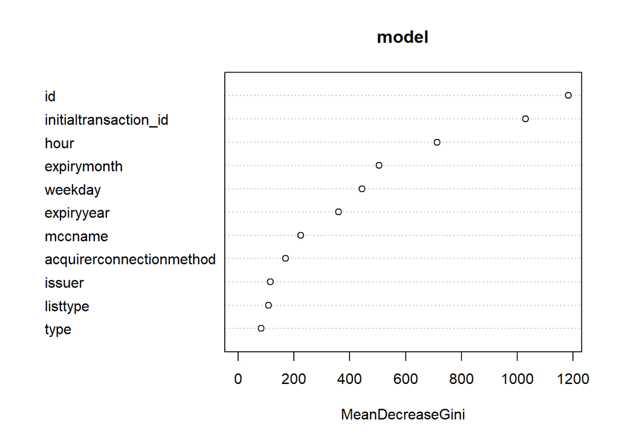

```r
varImpPlot(model)
```

Model jest w stanie poprawnie sklasyfikować dane w około 89,11% przypadków.

Model dobrze radzi sobie z klasyfikacją klasy “sukces” (bardzo niski błąd klasyfikacji: 2,63%), ale ma trudności z poprawnym przewidywaniem klasy “porażka” (błąd klasyfikacji: 43,82%). Model dobrze nadaje się do zadań, w których klasa “sukces” jest ważniejsza niż “porażka”.

```r
predictions <- predict(model, newdata = proba_testowa)

# Tworzenie ramki danych z wynikami predykcji
results_df <- data.frame(id = proba_testowa$id, prediction = predictions)

# Wyświetlenie pierwszych 10 wierszy wyników
head(results_df, 10)
```

```
##        id prediction
## 1    2702     sukces
## 2   13081     sukces
## 3   24953    porażka
## 4   37326     sukces
## 5   49909    porażka
## 6   61613     sukces
## 7   73671     sukces
## 8   85455     sukces
## 9   97474     sukces
## 10 112341     sukces
```

```r
# Scalanie wyników predykcji z ramką danych testowych
predykcje_testowa <- merge(predykcje_testowa, results_df, by = "id", all.x = TRUE)

# Konwersja kolumny z predykcjami na czynnik
predykcje_testowa$status <- as.factor(predykcje_testowa$prediction)

# Usunięcie kolumny z surowymi predykcjami
predykcje_testowa$prediction <- NULL

# Wyświetlenie pierwszych 10 wierszy przetworzonej ramki danych
head(predykcje_testowa, 10)
```

```
##      id amount  status
## 1  2445     NA  sukces
## 2  2480     NA porażka
## 3  2481     NA porażka
## 4  2494     NA  sukces
## 5  2498     NA  sukces
## 6  2521     NA  sukces
## 7  2525     NA  sukces
## 8  2526     NA  sukces
## 9  2551     NA  sukces
## 10 2563     NA  sukces
```

# #ZADANIE 2 - WSTĘPNA EKSPLORACJA DANYCH

```r
summary(proba_uczaca)
```

```
##        id         initialtransaction_id     amount
##  Min.   :  2441   Min.   :    17        Min.   :   0.81
##  1st Qu.: 48222   1st Qu.:  1673        1st Qu.:  25.00
##  Median : 86192   Median : 25840        Median :  30.00
##  Mean   : 85270   Mean   : 37567        Mean   :  63.42
##  3rd Qu.:123704   3rd Qu.: 64465        3rd Qu.:  50.00
##  Max.   :162463   Max.   :162231        Max.   :2712.64
##
##  acquirerconnectionmethod  expirymonth       expiryyear          issuer
##  ECARD_REST: 1848         Min.   : 1.000   Min.   :2020   MAESTRO   :   23
##  FDP_SOAP  :23603         1st Qu.: 3.000   1st Qu.:2022   MASTERCARD:11669
##                           Median : 7.000   Median :2023   VISA      :13759
##                           Mean   : 6.487   Mean   :2023
##                           3rd Qu.: 9.000   3rd Qu.:2024
##                           Max.   :12.000   Max.   :2029
##
##      type            level       countrycode         listtype
##  CREDIT: 3556   CLASSIC :9224   PL     :23192   ECOMMERCE:20818
##  DEBIT :21895   STANDARD:8800   GB     : 1176   MWF      : 4319
##                 GOLD    :2458   UA     :  352   PUBLIC   :  314
##                 BUSINESS:2234   BY     :  144
##                 ELECTRON: 930   US     :  136
##                 WORLD   : 543   TR     :   77
##                 (Other) :1262   (Other):  374
##                                               mccname          status
##  NULL                                             :  694   porażka: 5064
##  Restauracja                                      :   22   sukces :20387
##  Sieci komputerowe usługi informacyjne            : 5885
##  Sklepy spożywcze różne                           :   83
##  Ubezpieczenia                                    :  561
##  Usługi biznesowe gdzie indziej nie sklasyfikowane:18206
##
##          weekday          hour
##  czwartek    :3591   Min.   : 0.00
##  niedziela   :2809   1st Qu.: 7.00
##  piątek      :3715   Median : 9.00
##  poniedziałek:4494   Mean   :11.35
##  sobota      :2817   3rd Qu.:16.00
##  środa       :3749   Max.   :23.00
##  wtorek      :4276
```

```r
sum(is.na(proba_uczaca))
```

```
## [1] 0
```

```r
sapply(proba_uczaca, function(x) sum(is.na(x)))
```

```
##                       id    initialtransaction_id                   amount
##                        0                        0                        0
## acquirerconnectionmethod              expirymonth               expiryyear
##                        0                        0                        0
##                   issuer                     type                    level
##                        0                        0                        0
##              countrycode                 listtype                  mccname
##                        0                        0                        0
##                   status                  weekday                     hour
##                        0                        0                        0
```

#BUDOWANIE MODELI

```r
# Usuwanie ekstremów

# Podsumowanie i obliczenie odchylenia standardowego dla kolumny 'amount'
summary(proba_uczaca$amount)
```

```
##    Min. 1st Qu.  Median    Mean 3rd Qu.    Max.
##    0.81   25.00   30.00   63.42   50.00 2712.64
```

```r
odchylenie_standardowe <- sd(proba_uczaca$amount, na.rm = TRUE)

# Wyświetlenie obliczonego odchylenia standardowego
print(odchylenie_standardowe)
```

```
## [1] 127.4308
```

```r
# Oczyszczanie danych z wartości powyżej 180
proba_uczaca <- proba_uczaca %>% filter(amount < 180)
```

```r
drzewo_regresji <- rpart(amount ~ ., data = proba_uczaca, method = "anova")

# Zastosowanie funkcji 'tapply' do sumowania 'amount' w poszczególnych węzłach drzewa
suma_w_wezlach <- tapply(proba_uczaca$amount, INDEX = drzewo_regresji$where, FUN = sum)

# Sprawdzanie wyników
print(suma_w_wezlach)
```

```
##         3         6         7         8         9
## 363436.06  10150.00 245024.91  39813.35 302910.98
```

```r
węzły <- drzewo_regresji$where
```

## Tworzenie dwóch podzbiorów z proby uczacej

Tworzymy grupę_uczącą2 oraz grupę_walidacyjną2.

```r
set.seed(120)

#Kod usuwa kolumny level, countrycode z ramki danych proba_uczaca.
test2 <- proba_uczaca %>% select(-level, -countrycode, -status)

grupy2 <- rep(c("uczacy", "walidacyjny" ), round(c(0.7, 0.3)*nrow(proba_uczaca)))

grupy2 <- sample(grupy2)

grupa_uczaca2 <- test2[grupy2 == 'uczacy',]
grupa_walidacyjna2 <- test2[grupy2 == 'walidacyjny',]
```

# Sprawdzanie poziomów

```r
# Zidentyfikowanie kolumn faktorowych w zbiorze danych
factor_columns_check <- names(grupa_uczaca2)[sapply(grupa_uczaca2, is.factor)]

# Weryfikacja poziomów zmiennych faktorowych
for (column in factor_columns_check) {
  cat("\nSprawdzanie poziomów dla zmiennej:", column, "\n")

  # Pobieranie poziomów zmiennych z obu zbiorów (treningowego i testowego)
  levels_train <- levels(grupa_uczaca2[[column]])
  levels_test <- levels(proba_testowa[[column]])

  if (identical(levels_train, levels_test)) {
    cat("Poziomy są identyczne w obu zbiorach.\n")
  } else {
    cat("Poziomy są różne\n")
    cat("Poziomy w 'grupa_uczaca2':", paste(levels_train, collapse = ", "), "\n")
    cat("Poziomy w 'proba_testowa':", paste(levels_test, collapse = ", "), "\n")
  }
}
```

```
##
## Sprawdzanie poziomów dla zmiennej: acquirerconnectionmethod
## Poziomy są identyczne w obu zbiorach.
##
## Sprawdzanie poziomów dla zmiennej: issuer
## Poziomy są identyczne w obu zbiorach.
##
## Sprawdzanie poziomów dla zmiennej: type
## Poziomy są identyczne w obu zbiorach.
##
## Sprawdzanie poziomów dla zmiennej: listtype
## Poziomy są identyczne w obu zbiorach.
##
## Sprawdzanie poziomów dla zmiennej: mccname
## Poziomy są identyczne w obu zbiorach.
##
## Sprawdzanie poziomów dla zmiennej: weekday
## Poziomy są identyczne w obu zbiorach.
```

# Drzewo regresyjne właściwe

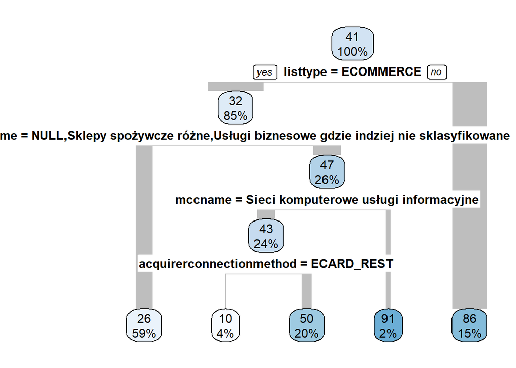

```r
# Budowanie drzewa regresyjnego z kontrolą nad parametrami
drzewo_regresji <- rpart(amount ~ ., data = grupa_uczaca2, method = "anova", control = rpart.control(cp = 0.01), model = TRUE)

# Wizualizacja drzewa
rpart.plot(drzewo_regresji, branch.type = 1)
```

```r
# Predykcje dla zbioru walidacyjnego
predykcje_testowe <- predict(drzewo_regresji, newdata = grupa_walidacyjna2)

# Predykcje dla zbioru uczącego
predykcje_uczace <- predict(drzewo_regresji, newdata = grupa_uczaca2)

# Wyświetlenie wyników predykcji dla danych walidacyjnych
head(predykcje_testowe)
```

```
##        2        3        6       10       13       17
## 26.05603 26.05603 26.05603 86.43768 86.43768 86.43768
```

# Test jakości

```r
# Obliczenie błędów dla zbiorów treningowego i testowego
train_residuals <- grupa_uczaca2$amount - predykcje_uczace
test_residuals <- grupa_walidacyjna2$amount - predykcje_testowe
# MSE: średni błąd kwadratowy
mse_train_new <- mean(train_residuals^2)
mse_test_new <- mean(test_residuals^2)
# MAE: średni błąd absolutny
mae_train_new <- mean(abs(train_residuals))
mae_test_new <- mean(abs(test_residuals))
# R²: współczynnik determinacji
total_train_variance <- sum((grupa_uczaca2$amount - mean(grupa_uczaca2$amount))^2)
total_test_variance <- sum((grupa_walidacyjna2$amount - mean(grupa_walidacyjna2$amount))^2)
r2_train_new <- 1 - (sum(train_residuals^2) / total_train_variance)
r2_test_new <- 1 - (sum(test_residuals^2) / total_test_variance)
# Wyświetlenie wyników
cat("MSE dla zbioru treningowego:", mse_train_new, "MSE dla zbioru testowego:", mse_test_new, "\n")
```

```
## MSE dla zbioru treningowego: 478.6236 MSE dla zbioru testowego: 438.9036
```

```r
cat("MAE dla zbioru treningowego:", mae_train_new, "MAE dla zbioru testowego:", mae_test_new, "\n")
```

```
## MAE dla zbioru treningowego: 12.0872 MAE dla zbioru testowego: 11.54248
```

```r
cat("R² dla zbioru treningowego:", r2_train_new, "R² dla zbioru testowego:", r2_test_new, "\n")
```

```
## R² dla zbioru treningowego: 0.5331294 R² dla zbioru testowego: 0.5439404
```

#Predykcja

```r
# Dokonywanie predykcji na zestawie testowym
predictions_test <- predict(drzewo_regresji, newdata = proba_testowa)

# Tworzenie ramki danych z wynikami
results_test <- data.frame(id = proba_testowa$id, prediction_value = predictions_test)

# Wyświetlenie pierwszych 20 wyników
head(results_test, 20)
```

```
##        id prediction_value
## 1    2702         26.05603
## 2   13081         26.05603
## 3   24953         26.05603
## 4   37326         26.05603
## 5   49909         26.05603
## 6   61613         26.05603
## 7   73671         26.05603
## 8   85455         26.05603
## 9   97474         26.05603
## 10 112341         26.05603
## 11 126788         26.05603
## 12 143969         26.05603
## 13   2684         26.05603
## 14  13056         26.05603
## 15  24921         26.05603
## 16  37299         26.05603
## 17  49881         26.05603
## 18  61579         26.05603
## 19  73655         26.05603
## 20  85404         26.05603
```

```r
# Łączenie nowych wyników z istniejącymi predykcjami
predykcje_testowa <- merge(predykcje_testowa, results_test, by = "id", all.x = TRUE)

# Konwertowanie kolumny 'prediction_value' na wartości numeryczne
predykcje_testowa$amount <- as.numeric(predykcje_testowa$prediction_value)

# Usunięcie kolumny 'prediction_value'
predykcje_testowa$prediction_value <- NULL

# Wyświetlenie pierwszych 40 wyników po zmianach
head(predykcje_testowa, 40)
```

```
##      id   amount  status
## 1  2445 26.05603  sukces
## 2  2480 10.00000 porażka
## 3  2481 10.00000 porażka
## 4  2494 26.05603  sukces
## 5  2498 26.05603  sukces
## 6  2521 86.43768  sukces
## 7  2525 86.43768  sukces
## 8  2526 86.43768  sukces
## 9  2551 86.43768  sukces
## 10 2563 26.05603  sukces
## 11 2604 26.05603  sukces
## 12 2608 26.05603  sukces
## 13 2622 26.05603  sukces
## 14 2624 26.05603  sukces
```

[output cut: 26 more lines]